# Climate Report

Temperature and Precipitation 1960-2014

Evan Ortega

May 10, 2019

### Data

The data comes from the “temp-prec-encrypted.csv.bz2” file. It is decrypted through the decryptData function in the “decrypt” package. For the air temperature maps, I took the data from the specific months/years given where the “airtemp” column had an actual value instead of just “NA”. I did the same with the precipitation maps, but with the “precipitation” column.

### Temperature

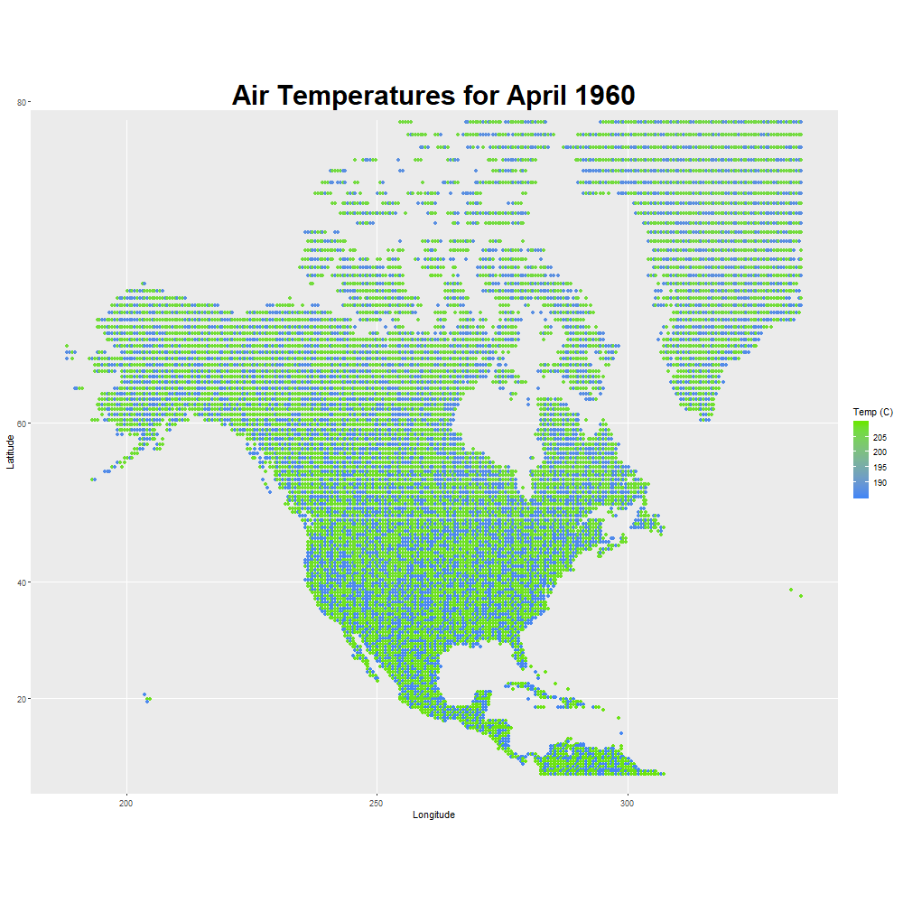

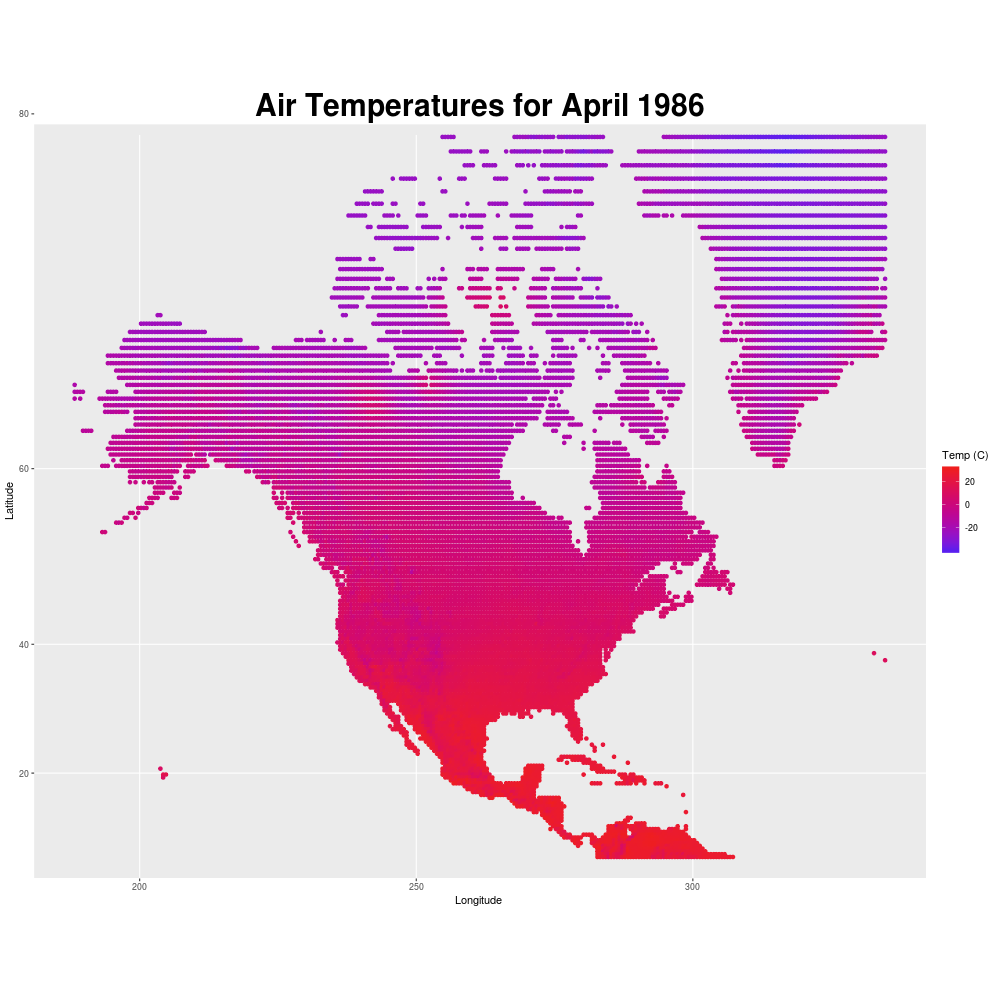

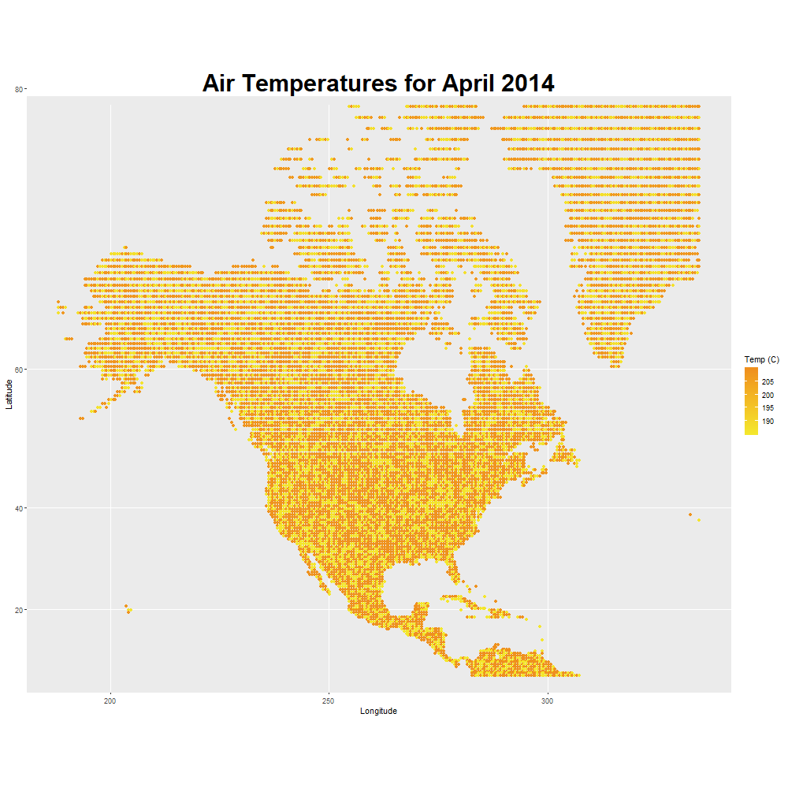

I didn’t find a pattern in the data for either 1960 or 2014. I used blue-green and yellow-orange respectively to contrast the extreme temperatures and they’re all over the place. However, with the data from April 1986, there was a clear correlation between latitude and air temperature. The temperatures were lower, around -20 Celsius, north of the 60-degree line. Greenland, Alaska, and Northern Canada had notably low temperatures. Mexico, Central America, and the Caribbean had the highest temperatures. I also noticed that the western US had areas with cold temperatures.

### Precipitation

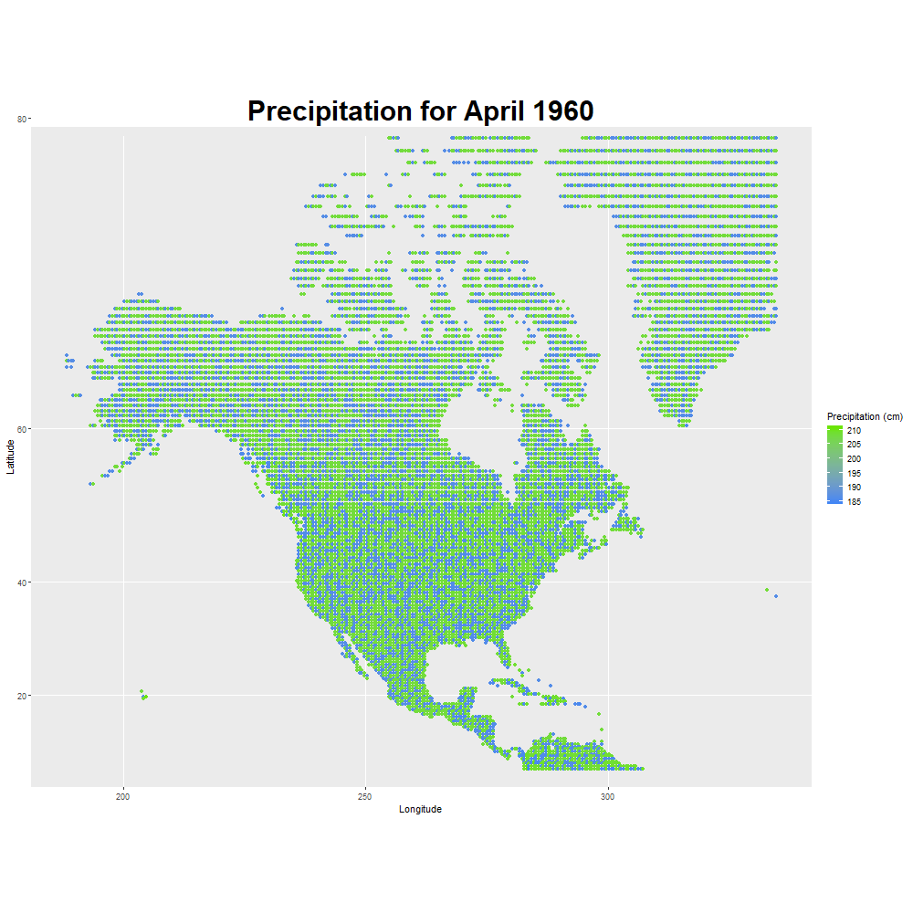

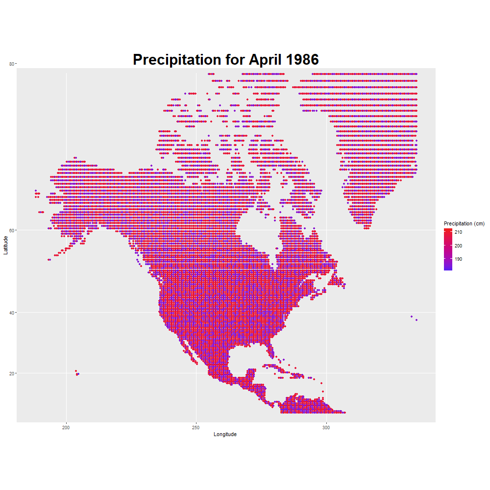

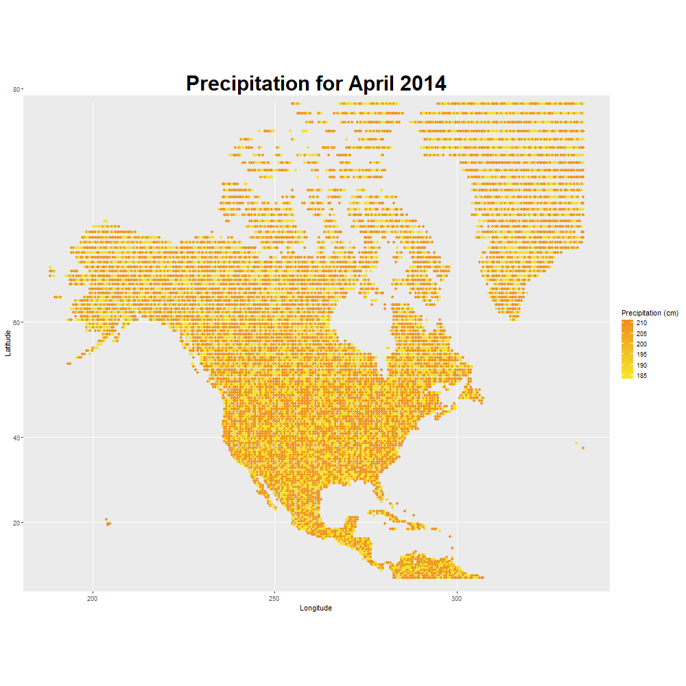

Just like two of the temperature maps, I cannot find any pattern among the precipitation maps. The extremes of rainfall, about 185cm and 210cm, were scattered equally throughout North America. This is likely because the range of values is very small at about 25cm, or 9 inches. Especially since this is a sum of the rainfall for that month, it makes sense to me why there would be no pattern.